# GCDS Final

Kayleah, Brian, Rebecca

2022-11-17

```r
rm(list = ls(all.names = TRUE))      # remove objects in R
source("https://pastebin.com/raw/8mXH02yg")   # run and comment out after knitting
source("https://pastebin.com/raw/97NNTTzu")   # run to include in function definitions
```

```
## Loading custom functions...
```

```
## Done
```

```r
# set the paths for project, script, and data dirs
proj_dir <- gsub("GCDS.*.Rmd", "GCDS", get_ActivePath())
proj_name = ""
r_dir    <- paste(proj_dir, "r", sep = "/")    # r subdir
data_dir <- paste(proj_dir, "data", sep = "/") # data subdir
if ( proj_name != "" & !dir.exists(paste(proj_dir, proj_name, sep = "/")) ) {
# create project dir
suppressWarnings(dir.create(paste(proj_dir, proj_name, sep = "/")))
r_dir <- gsub("/r", paste0("/", proj_name, "/r"), r_dir)
data_dir <- gsub("/data", paste0("/", proj_name, "/data"), data_dir)
# create sub directories
suppressWarnings(dir.create(r_dir))
suppressWarnings(dir.create(data_dir)) }
```

# **DATA PREPARATION**

## General Game Survey

### *Cleaning/Tidying Data*

1. Read the .csv into an object
2. Filter out bad/incomplete data (i.e., the invalid 99999 id and the unfinished responses)
3. Select only relevant columns (i.e., code ID and Game variables)
4. Convert all the data to numeric
5. For clustering, remove all NAs
6. Remove the automated row numbers because they mess with k-means clustering
7. Scale all the numeric variables except for the code values, for NAs impute in 0 instead
8. Add the code values back to the scaled dataframe

```r
# General Survey, cleaned (GS)
GSOG <- read.csv("GCDS22_11-15_numeric.csv")

GS <- GSOG %>%
  filter(code < 2100, Finished == 1) %>%
  select(-c(1:17))

GS <- mutate_all(GS, function(x) as.numeric(as.character(x)))

view(GS)
```

|  | code | Challenge | Breadth | Relationships | Competition | PleasureMost | Pleasure__1 | Pleasure__2 | Pleasure__3 | Pleasure__4 | Pleasure__5 | Pleasure__6 | Pleasure__7 | Pleasure__8 | Pleasure__9 | Pleasure__10 | Pleasure__11 | Fantasy | Narrative | Challenge.1 | Fellowship | Discovery | Expression | Submission | Design_1 | Design_2 | Design_3 | Design_4 | Design_5 | … |
| --- | --- | --- | --- | --- | --- | --- | --- | --- | --- | --- | --- | --- | --- | --- | --- | --- | --- | --- | --- | --- | --- | --- | --- | --- | --- | --- | --- | --- | --- | --- |
| 1 | 1002 | 6 | 6 | 6 | 6 | 3 | 1 | 1 | 1 | 1 | 1 | 1 | 1 | 1 | 1 | 1 | 1 | 2 | 5 | 5 | 6 | 5 | 4 | 4 | 1 | 1 | 99 | 1 | 1 | … |
| 2 | 1001 | 6 | 6 | 6 | 6 | 3 | 1 | 1 | 1 | 1 | 1 | 1 | 1 | 1 | 1 | 1 | 1 | 4 | 2 | 6 | 6 | 5 | 4 | 3 | 99 | 99 | 1 | 1 | 0 | … |
| 3 | 1004 | 6 | 6 | 5 | 6 | 2 | 1 | 1 | 1 | 1 | 1 | 0 | 1 | 1 | 1 | 1 | 1 | 2 | 3 | 4 | 5 | 5 | 5 | 3 | 1 | 1 | 1 | 1 | 1 | … |
| 4 | 1003 | 5 | 2 | 5 | 5 | 3 | 0 | 1 | 0 | 0 | 1 | 0 | 1 | 1 | 1 | 1 | 0 | 1 | 2 | 4 | 4 | 2 | 1 | 1 | 0 | 0 | 0 | 0 | 0 | … |
| 5 | 1905 | 5 | 4 | 6 | 5 | 3 | 1 | 1 | 1 | 1 | 1 | 0 | 1 | 0 | 1 | 1 | 1 | 2 | 2 | 4 | 6 | 4 | 3 | 3 | 1 | 1 | 1 | 0 | 1 | … |
| 6 | 1903 | 5 | 5 | 6 | 4 | 3 | 1 | 1 | 1 | 1 | 1 | 1 | 1 | 1 | 1 | 1 | 1 | 4 | 5 | 5 | 6 | 4 | 4 | 4 | 1 | 1 | 1 | 1 | 99 | … |
| 7 | 1902 | 5 | 6 | 6 | 5 | 3 | 1 | 1 | 1 | 0 | 1 | 1 | 1 | 1 | 1 | 1 | 1 | 1 | 5 | 6 | 5 | 6 | 5 | 1 | 99 | 99 | 99 | 1 | 1 | … |
| 8 | 1705 | 5 | 3 | 5 | 6 | 3 | 1 | 1 | 1 | 0 | 1 | 0 | 0 | 0 | 0 | 0 | 0 | 1 | 4 | 5 | 5 | 1 | 3 | 2 | 0 | 1 | 99 | 99 | 99 | … |
| 9 | 2002 | 5 | 4 | 5 | 3 | 3 | 1 | 1 | 0 | 0 | 1 | 1 | 0 | 1 | 1 | 1 | 1 | 4 | 4 | 4 | 5 | 3 | 2 | 4 | 1 | 0 | 99 | 1 | 1 | … |
| 10 | 1904 | 5 | 4 | 5 | 4 | 1 | 1 | 1 | 1 | 1 | 1 | 1 | 1 | 1 | 1 | 1 | 1 | 3 | 4 | 5 | 5 | 4 | 3 | 3 | 1 | 1 | 1 | 1 | 1 | … |

[output cut: 28 more lines]

```r
GS_for_clustering <- GS %>% select_if(~ !any(is.na(.)))

row.names(GS_for_clustering) <- GS_for_clustering$code

GS_for_clustering <- GS_for_clustering[, -1]

GS_z <- GS_for_clustering %>%
  mutate(., across(.fns = ~na_if(., 99))) %>%
  mutate(., across(.cols = where(is.numeric),
                   .fns = ~as.numeric(scale(.x)),
                   .names = "{.col}")) %>%
  select(!c(Pleasure__2, Design_7)) %>%
  mutate(., across(.fns = ~replace_na(.x, 0)))

GS_z$code <- GS$code

view(GS_z)
```

|  | Challenge | Breadth | Relationships | Competition | PleasureMost | Pleasure__1 | Pleasure__3 | Pleasure__4 | Pleasure__5 | Pleasure__6 | Pleasure__7 | Pleasure__8 | Pleasure__9 | Pleasure__10 | Pleasure__11 | Fantasy | Narrative | Challenge.1 | Fellowship | Discovery | Expression | Submission | Design_1 | Design_2 | Design_3 | Design_4 | Design_5 | Design_6 | Design_8 | … |
| --- | --- | --- | --- | --- | --- | --- | --- | --- | --- | --- | --- | --- | --- | --- | --- | --- | --- | --- | --- | --- | --- | --- | --- | --- | --- | --- | --- | --- | --- | --- |
| 1002 | 1.07546214241912 | 1.31995198256686 | 0.812929235594419 | 0.999107108512338 | 0.23258023830812 | 0.384093622292541 | 0.887817859348665 | 0.936117401544104 | 0.288892102032128 | 0.509557771805139 | 0.338453960814955 | 0.549707066026262 | 0.384093622292541 | 0.384093622292541 | 0.384093622292541 | -0.777657029316006 | 0.642175170382704 | 0.184656141628161 | 0.691628999677294 | 0.841985186445489 | 0.235684713232983 | 0.284798718433966 | 0.636755910587892 | 0.621059003408119 | 0 | 0.448496850922452 | 0.713477241231741 | 0 | -0.72956018567088 | … |
| 1001 | 1.07546214241912 | 1.31995198256686 | 0.812929235594419 | 0.999107108512338 | 0.23258023830812 | 0.384093622292541 | 0.887817859348665 | 0.936117401544104 | 0.288892102032128 | 0.509557771805139 | 0.338453960814955 | 0.549707066026262 | 0.384093622292541 | 0.384093622292541 | 0.384093622292541 | 0.596806557382051 | -1.7193722303795 | 1.35414503860651 | 0.691628999677294 | 0.841985186445489 | 0.235684713232983 | -0.436691368265414 | 0 | 0 | 0.690065559342354 | 0.448496850922452 | -1.34767923343773 | 0.179605302026775 | -0.72956018567088 | … |
| 1004 | 1.07546214241912 | 1.31995198256686 | -0.375198108735886 | 0.999107108512338 | -0.872175893655451 | 0.384093622292541 | 0.887817859348665 | 0.936117401544104 | 0.288892102032128 | -1.91084164426927 | 0.338453960814955 | 0.549707066026262 | 0.384093622292541 | 0.384093622292541 | 0.384093622292541 | -0.777657029316006 | -0.932189763458764 | -0.984832755350191 | -0.319213384466444 | 0.841985186445489 | 1.04986826803783 | -0.436691368265414 | 0.636755910587892 | 0.621059003408119 | 0.690065559342354 | 0.448496850922452 | 0.713477241231741 | 0.179605302026775 | 1.32647306485615 | … |
| 1003 | -0.384093622292542 | -2.13923252347043 | -0.375198108735886 | 0.173757758002146 | 0.23258023830812 | -2.53501790713077 | -1.09671617919541 | -1.04013044616012 | 0.288892102032128 | -1.91084164426927 | 0.338453960814955 | 0.549707066026262 | 0.384093622292541 | 0.384093622292541 | -2.53501790713077 | -1.46488882266503 | -1.7193722303795 | -0.984832755350191 | -1.33005576861018 | -1.61920228162594 | -2.20686595118157 | -1.87967154166418 | -1.51229528764624 | -1.5526475085203 | -1.38013111868471 | -2.15278488442777 | -1.34767923343773 | -5.38815906080325 | -0.72956018567088 | … |
| 1905 | -0.384093622292542 | -0.409640270451785 | 0.812929235594419 | 0.173757758002146 | 0.23258023830812 | 0.384093622292541 | 0.887817859348665 | 0.936117401544104 | 0.288892102032128 | -1.91084164426927 | 0.338453960814955 | -1.7712783238624 | 0.384093622292541 | 0.384093622292541 | 0.384093622292541 | -0.777657029316006 | -1.7193722303795 | -0.984832755350191 | 0.691628999677294 | 0.0215893637550124 | -0.578498841571867 | -0.436691368265414 | 0.636755910587892 | 0.621059003408119 | 0.690065559342354 | -2.15278488442777 | 0.713477241231741 | 0 | 1.32647306485615 | … |
| 1903 | -0.384093622292542 | 0.455155856057539 | 0.812929235594419 | -0.651591592508047 | 0.23258023830812 | 0.384093622292541 | 0.887817859348665 | 0.936117401544104 | 0.288892102032128 | 0.509557771805139 | 0.338453960814955 | 0.549707066026262 | 0.384093622292541 | 0.384093622292541 | 0.384093622292541 | 0.596806557382051 | 0.642175170382704 | 0.184656141628161 | 0.691628999677294 | 0.0215893637550124 | 0.235684713232983 | 0.284798718433966 | 0.636755910587892 | 0.621059003408119 | 0.690065559342354 | 0.448496850922452 | 0 | 0.179605302026775 | -0.72956018567088 | … |
| 1902 | -0.384093622292542 | 1.31995198256686 | 0.812929235594419 | 0.173757758002146 | 0.23258023830812 | 0.384093622292541 | 0.887817859348665 | -1.04013044616012 | 0.288892102032128 | 0.509557771805139 | 0.338453960814955 | 0.549707066026262 | 0.384093622292541 | 0.384093622292541 | 0.384093622292541 | -1.46488882266503 | 0.642175170382704 | 1.35414503860651 | -0.319213384466444 | 1.66238100913597 | 1.04986826803783 | -1.87967154166418 | 0 | 0 | 0 | 0.448496850922452 | 0.713477241231741 | 0.179605302026775 | 0 | … |
| 1705 | -0.384093622292542 | -1.27443639696111 | -0.375198108735886 | 0.999107108512338 | 0.23258023830812 | 0.384093622292541 | 0.887817859348665 | -1.04013044616012 | 0.288892102032128 | -1.91084164426927 | -2.87685866692712 | -1.7712783238624 | -2.53501790713077 | -2.53501790713077 | -2.53501790713077 | -1.46488882266503 | -0.14500729653803 | 0.184656141628161 | -0.319213384466444 | -2.43959810431642 | -0.578498841571867 | -1.15818145496479 | -1.51229528764624 | 0.621059003408119 | 0 | 0 | 0 | 0.179605302026775 | -0.72956018567088 | … |
| 2002 | -0.384093622292542 | -0.409640270451785 | -0.375198108735886 | -1.47694094301824 | 0.23258023830812 | 0.384093622292541 | -1.09671617919541 | -1.04013044616012 | 0.288892102032128 | 0.509557771805139 | -2.87685866692712 | 0.549707066026262 | 0.384093622292541 | 0.384093622292541 | 0.384093622292541 | 0.596806557382051 | -0.14500729653803 | -0.984832755350191 | -0.319213384466444 | -0.798806458935465 | -1.39268239637672 | 0.284798718433966 | 0.636755910587892 | -1.5526475085203 | 0 | 0.448496850922452 | 0.713477241231741 | 0.179605302026775 | -0.72956018567088 | … |
| 1904 | -0.384093622292542 | -0.409640270451785 | -0.375198108735886 | -0.651591592508047 | -1.97693202561902 | 0.384093622292541 | 0.887817859348665 | 0.936117401544104 | 0.288892102032128 | 0.509557771805139 | 0.338453960814955 | 0.549707066026262 | 0.384093622292541 | 0.384093622292541 | 0.384093622292541 | -0.0904252359669775 | -0.14500729653803 | 0.184656141628161 | -0.319213384466444 | 0.0215893637550124 | -0.578498841571867 | -0.436691368265414 | 0.636755910587892 | 0.621059003408119 | 0.690065559342354 | 0.448496850922452 | 0.713477241231741 | 0.179605302026775 | 0 | … |

[output cut: 28 more lines]

```r
view(GS_for_clustering)
```

|  | Challenge | Breadth | Relationships | Competition | PleasureMost | Pleasure__1 | Pleasure__2 | Pleasure__3 | Pleasure__4 | Pleasure__5 | Pleasure__6 | Pleasure__7 | Pleasure__8 | Pleasure__9 | Pleasure__10 | Pleasure__11 | Fantasy | Narrative | Challenge.1 | Fellowship | Discovery | Expression | Submission | Design_1 | Design_2 | Design_3 | Design_4 | Design_5 | Design_6 | … |
| --- | --- | --- | --- | --- | --- | --- | --- | --- | --- | --- | --- | --- | --- | --- | --- | --- | --- | --- | --- | --- | --- | --- | --- | --- | --- | --- | --- | --- | --- | --- |
| 1002 | 6 | 6 | 6 | 6 | 3 | 1 | 1 | 1 | 1 | 1 | 1 | 1 | 1 | 1 | 1 | 1 | 2 | 5 | 5 | 6 | 5 | 4 | 4 | 1 | 1 | 99 | 1 | 1 | 99 | … |
| 1001 | 6 | 6 | 6 | 6 | 3 | 1 | 1 | 1 | 1 | 1 | 1 | 1 | 1 | 1 | 1 | 1 | 4 | 2 | 6 | 6 | 5 | 4 | 3 | 99 | 99 | 1 | 1 | 0 | 1 | … |
| 1004 | 6 | 6 | 5 | 6 | 2 | 1 | 1 | 1 | 1 | 1 | 0 | 1 | 1 | 1 | 1 | 1 | 2 | 3 | 4 | 5 | 5 | 5 | 3 | 1 | 1 | 1 | 1 | 1 | 1 | … |
| 1003 | 5 | 2 | 5 | 5 | 3 | 0 | 1 | 0 | 0 | 1 | 0 | 1 | 1 | 1 | 1 | 0 | 1 | 2 | 4 | 4 | 2 | 1 | 1 | 0 | 0 | 0 | 0 | 0 | 0 | … |
| 1905 | 5 | 4 | 6 | 5 | 3 | 1 | 1 | 1 | 1 | 1 | 0 | 1 | 0 | 1 | 1 | 1 | 2 | 2 | 4 | 6 | 4 | 3 | 3 | 1 | 1 | 1 | 0 | 1 | 99 | … |
| 1903 | 5 | 5 | 6 | 4 | 3 | 1 | 1 | 1 | 1 | 1 | 1 | 1 | 1 | 1 | 1 | 1 | 4 | 5 | 5 | 6 | 4 | 4 | 4 | 1 | 1 | 1 | 1 | 99 | 1 | … |
| 1902 | 5 | 6 | 6 | 5 | 3 | 1 | 1 | 1 | 0 | 1 | 1 | 1 | 1 | 1 | 1 | 1 | 1 | 5 | 6 | 5 | 6 | 5 | 1 | 99 | 99 | 99 | 1 | 1 | 1 | … |
| 1705 | 5 | 3 | 5 | 6 | 3 | 1 | 1 | 1 | 0 | 1 | 0 | 0 | 0 | 0 | 0 | 0 | 1 | 4 | 5 | 5 | 1 | 3 | 2 | 0 | 1 | 99 | 99 | 99 | 1 | … |
| 2002 | 5 | 4 | 5 | 3 | 3 | 1 | 1 | 0 | 0 | 1 | 1 | 0 | 1 | 1 | 1 | 1 | 4 | 4 | 4 | 5 | 3 | 2 | 4 | 1 | 0 | 99 | 1 | 1 | 1 | … |
| 1904 | 5 | 4 | 5 | 4 | 1 | 1 | 1 | 1 | 1 | 1 | 1 | 1 | 1 | 1 | 1 | 1 | 3 | 4 | 5 | 5 | 4 | 3 | 3 | 1 | 1 | 1 | 1 | 1 | 1 | … |

[output cut: 28 more lines]

### *Gathering continuous variables for clustering*

Qualtrics returns numeric data as character objects, so we have to convert all of them to numeric in order to calculate means.

```r
# General Survey w/ only continuous variables (GS_c)
GS_c <- GS_for_clustering %>%
  select(!c(Pleasure__1:Pleasure__11, Challenge.1))

GS_c <- mutate_all(GS_c, function(x) as.numeric(as.character(x)))
```

## Individual post-gameplay responses

### *Cleaning/Tidying Data*

1. Read game csv into an object
2. Slice out the rows that aren’t participant data
3. Select only relevant columns (i.e., code ID and response variables)

```r
# Love Letter (LL)
LL <- readr::read_csv("LoveLetter_11-15_numeric.csv")
LL <- LL %>%
  slice(3:42) %>%
  select(-c(1:17))
View(LL)

# Taco Cat Goat Cheese Pizza (TC)
TC <- readr::read_csv("TacoCat_11-15_numeric.csv")
TC <- TC %>%
  slice(3:37) %>%
  select(-c(1:17))
View(TC)

# Codenames (CD)
CD <- readr::read_csv("Codenames_11-15_numeric.csv")
CD <- CD %>%
  slice(3:16) %>%
  select(-c(1:17))
View(CD)

# Chronology (CH)
CH <- readr::read_csv("Chronology_11-15_numeric.csv")
CH <- CH %>%
  slice(3:32) %>%
  select(-c(1:17))
View(CH)
```

### Finding the average scores for each trait for each game

```r
# Love Letter (LL)
LLScores <- LL %>%
  na.omit(.) %>%
  mutate_all(., function(x) as.numeric(as.character(x))) %>%
  select(-code, -win) %>%
  colMeans(.)

View(LLScores)

# Taco Cat Goat Cheese Pizza (TC)
TCScores <- TC %>%
  na.omit(.) %>%
  mutate_all(., function(x) as.numeric(as.character(x))) %>%
  select(-code, -win) %>%
  colMeans(.)
View(TCScores)

# Codenames (CD)
CDScores <- CD %>%
  na.omit(.) %>%
  mutate_all(., function(x) as.numeric(as.character(x))) %>%
  select(-code, -win) %>%
  colMeans(.)

View(CDScores)

# Chronology (CH)
CHScores <- CH %>%
  na.omit(.) %>%
  mutate_all(., function(x) as.numeric(as.character(x))) %>%
  select(-code, -win) %>%
  colMeans(.)
View(CHScores)
```

# **Clustering**

## General Game Survey

### *K-means clustering on the General Game Survey*

Set a “random” seed value so the data is reproducible

Run the k-means algorithm with a specified number of clusters and a number of trials. 25 ensures that the best option is chosen.

```r
set.seed(123)
k5 <- kmeans(GS_c, 5, nstart = 25)
k4 <- kmeans(GS_c, 4, nstart = 25)
k3 <- kmeans(GS_c, 3, nstart = 25)
k2 <- kmeans(GS_c, 2, nstart = 25)

# Print the results
str(k4)
```

```
## List of 9
##  $ cluster     : Named int [1:38] 3 4 1 4 2 3 4 1 2 4 ...
##   ..- attr(*, "names")= chr [1:38] "1002" "1001" "1004" "1003" ...
##  $ centers     : num [1:4, 1:133] 5.46 5.11 5.1 5.33 4.31 ...
##   ..- attr(*, "dimnames")=List of 2
##   .. ..$ : chr [1:4] "1" "2" "3" "4"
##   .. ..$ : chr [1:133] "Challenge" "Breadth" "Relationships" "Competition" ...
##  $ totss       : num 5271420
##  $ withinss    : num [1:4] 771970 882940 1289514 924757
##  $ tot.withinss: num 3869180
##  $ betweenss   : num 1402240
##  $ size        : int [1:4] 13 9 10 6
##  $ iter        : int 4
##  $ ifault      : int 0
##  - attr(*, "class")= chr "kmeans"
```

```r
print(k4)
```

```
## K-means clustering with 4 clusters of sizes 13, 9, 10, 6
##
## Cluster means:
##   Challenge  Breadth Relationships Competition PleasureMost  Fantasy Narrative
## 1  5.461538 4.307692      4.923077    5.000000     3.153846 2.769231  4.153846
## 2  5.111111 3.888889      5.444444    4.555556     2.666667 3.555556  4.333333
## 3  5.100000 5.000000      5.600000    4.600000     2.600000 3.400000  4.700000
## 4  5.333333 4.833333      5.500000    5.000000     2.500000 2.833333  3.166667
##   Fellowship Discovery Expression Submission Design_1 Design_2 Design_3
## 1   5.076923  3.615385   3.769231   3.692308 53.53846 31.00000 30.84615
## 2   5.666667  4.000000   3.666667   4.000000 11.66667 11.33333 55.33333
## 3   5.700000  4.100000   3.900000   3.700000  0.90000 20.60000 49.90000
## 4   4.666667  4.500000   3.333333   2.666667 49.66667 49.83333 49.83333
##     Design_4 Design_5 Design_6  Design_7 Design_8 Design_9 Design_10     PLAY
## 1 31.1538462 38.38462 23.61538  8.538462 23.30769 15.76923  15.84615 1.076923
```

[output cut: 95 more lines]

## Visualize the clusters

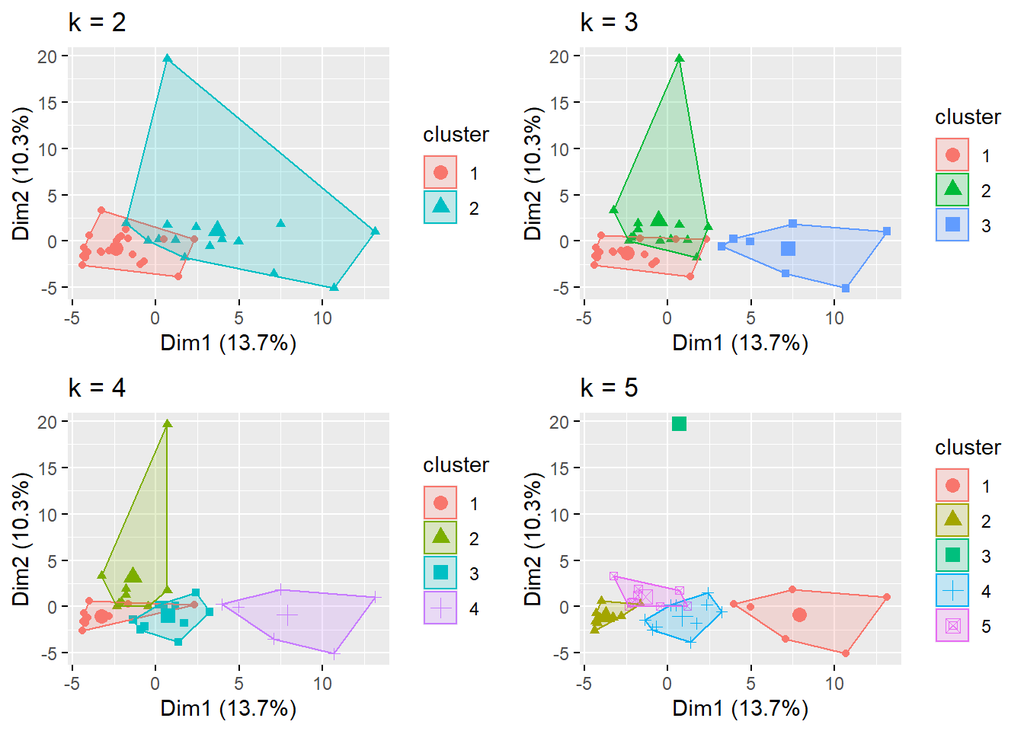

```r
# plots to compare
p1 <- fviz_cluster(k2, geom = "point", data = GS_c) + ggtitle("k = 2")
p2 <- fviz_cluster(k3, geom = "point",  data = GS_c) + ggtitle("k = 3")
p3 <- fviz_cluster(k4, geom = "point",  data = GS_c) + ggtitle("k = 4")
p4 <- fviz_cluster(k5, geom = "point",  data = GS_c) + ggtitle("k = 5")

library(dplyr)
library(gridExtra)
grid.arrange(p1, p2, p3, p4, nrow = 2)
```

# **Cognitive Task Analysis**

## Stroop Task

### *Top 5 Processing Speed on Stroop Task*

Identifying the top 5 participants based on reaction time on congruent stroop tasks. This translates to fast processing speeds.

```r
source("Stroop Task Analysis.R", local = knitr::knit_global())
view(stroopdat)
```

|  | id | odd | trialtype | rt | incongruent | q25 |
| --- | --- | --- | --- | --- | --- | --- |
| 1 | 1303 | 1 | congruent | 677.197916666667 | 0 | 746.222135416667 |
| 2 | 1404 | 0 | congruent | 691.816666666667 | 0 | 746.222135416667 |
| 3 | 1405 | 1 | congruent | 631.971875 | 0 | 746.222135416667 |
| 4 | 1902 | 0 | congruent | 652.708333333333 | 0 | 746.222135416667 |
| 5 | 1903 | 1 | congruent | 702.413541666667 | 0 | 746.222135416667 |

```r
top5 <- pull(stroopdat, id)
```

# **Filtering the Target Group**

## Stroop Task

### *Filtering out the top5 people from stroop*

Filter into two dataframes the people in the top5 and the people not in the top5

```r
top5General <- GS %>% filter(., code %in% top5)

notop5General <- GS %>% filter(., !(code %in% top5))

view(top5General)
```

|  | code | Challenge | Breadth | Relationships | Competition | PleasureMost | Pleasure__1 | Pleasure__2 | Pleasure__3 | Pleasure__4 | Pleasure__5 | Pleasure__6 | Pleasure__7 | Pleasure__8 | Pleasure__9 | Pleasure__10 | Pleasure__11 | Fantasy | Narrative | Challenge.1 | Fellowship | Discovery | Expression | Submission | Design_1 | Design_2 | Design_3 | Design_4 | Design_5 | … |
| --- | --- | --- | --- | --- | --- | --- | --- | --- | --- | --- | --- | --- | --- | --- | --- | --- | --- | --- | --- | --- | --- | --- | --- | --- | --- | --- | --- | --- | --- | --- |
| 1 | 1903 | 5 | 5 | 6 | 4 | 3 | 1 | 1 | 1 | 1 | 1 | 1 | 1 | 1 | 1 | 1 | 1 | 4 | 5 | 5 | 6 | 4 | 4 | 4 | 1 | 1 | 1 | 1 | 99 | … |
| 2 | 1902 | 5 | 6 | 6 | 5 | 3 | 1 | 1 | 1 | 0 | 1 | 1 | 1 | 1 | 1 | 1 | 1 | 1 | 5 | 6 | 5 | 6 | 5 | 1 | 99 | 99 | 99 | 1 | 1 | … |
| 3 | 1405 | 5 | 4 | 6 | 5 | 3 | 1 | 1 | 1 | 0 | 1 | 0 | 0 | 1 | 1 | 1 | 1 | 3 | 5 | 5 | 6 | 2 | 5 | 2 | 1 | 1 | 99 | 1 | 0 | … |
| 4 | 1303 | 5 | 5 | 5 | 4 | 3 | 1 | 1 | 1 | 1 | 1 | 1 | 1 | 1 | 1 | 1 | 1 | 2 | 4 | 5 | 5 | 3 | 4 | 4 | 1 | 1 | 1 | 1 | 0 | … |

```r
view(notop5General)
```

|  | code | Challenge | Breadth | Relationships | Competition | PleasureMost | Pleasure__1 | Pleasure__2 | Pleasure__3 | Pleasure__4 | Pleasure__5 | Pleasure__6 | Pleasure__7 | Pleasure__8 | Pleasure__9 | Pleasure__10 | Pleasure__11 | Fantasy | Narrative | Challenge.1 | Fellowship | Discovery | Expression | Submission | Design_1 | Design_2 | Design_3 | Design_4 | Design_5 | … |
| --- | --- | --- | --- | --- | --- | --- | --- | --- | --- | --- | --- | --- | --- | --- | --- | --- | --- | --- | --- | --- | --- | --- | --- | --- | --- | --- | --- | --- | --- | --- |
| 1 | 1002 | 6 | 6 | 6 | 6 | 3 | 1 | 1 | 1 | 1 | 1 | 1 | 1 | 1 | 1 | 1 | 1 | 2 | 5 | 5 | 6 | 5 | 4 | 4 | 1 | 1 | 99 | 1 | 1 | … |
| 2 | 1001 | 6 | 6 | 6 | 6 | 3 | 1 | 1 | 1 | 1 | 1 | 1 | 1 | 1 | 1 | 1 | 1 | 4 | 2 | 6 | 6 | 5 | 4 | 3 | 99 | 99 | 1 | 1 | 0 | … |
| 3 | 1004 | 6 | 6 | 5 | 6 | 2 | 1 | 1 | 1 | 1 | 1 | 0 | 1 | 1 | 1 | 1 | 1 | 2 | 3 | 4 | 5 | 5 | 5 | 3 | 1 | 1 | 1 | 1 | 1 | … |
| 4 | 1003 | 5 | 2 | 5 | 5 | 3 | 0 | 1 | 0 | 0 | 1 | 0 | 1 | 1 | 1 | 1 | 0 | 1 | 2 | 4 | 4 | 2 | 1 | 1 | 0 | 0 | 0 | 0 | 0 | … |
| 5 | 1905 | 5 | 4 | 6 | 5 | 3 | 1 | 1 | 1 | 1 | 1 | 0 | 1 | 0 | 1 | 1 | 1 | 2 | 2 | 4 | 6 | 4 | 3 | 3 | 1 | 1 | 1 | 0 | 1 | … |
| 6 | 1705 | 5 | 3 | 5 | 6 | 3 | 1 | 1 | 1 | 0 | 1 | 0 | 0 | 0 | 0 | 0 | 0 | 1 | 4 | 5 | 5 | 1 | 3 | 2 | 0 | 1 | 99 | 99 | 99 | … |
| 7 | 2002 | 5 | 4 | 5 | 3 | 3 | 1 | 1 | 0 | 0 | 1 | 1 | 0 | 1 | 1 | 1 | 1 | 4 | 4 | 4 | 5 | 3 | 2 | 4 | 1 | 0 | 99 | 1 | 1 | … |
| 8 | 1904 | 5 | 4 | 5 | 4 | 1 | 1 | 1 | 1 | 1 | 1 | 1 | 1 | 1 | 1 | 1 | 1 | 3 | 4 | 5 | 5 | 4 | 3 | 3 | 1 | 1 | 1 | 1 | 1 | … |
| 9 | 1901 | 5 | 6 | 5 | 6 | 4 | 1 | 1 | 1 | 0 | 1 | 1 | 1 | 1 | 1 | 1 | 1 | 5 | 4 | 5 | 4 | 5 | 4 | 4 | 99 | 1 | 99 | 0 | 99 | … |
| 10 | 2001 | 6 | 5 | 5 | 6 | 4 | 1 | 1 | 0 | 0 | 1 | 1 | 1 | 1 | 1 | 1 | 1 | 4 | 5 | 6 | 6 | 4 | 4 | 4 | 99 | 99 | 99 | 1 | 1 | … |

[output cut: 24 more lines]

# **Analyzing Target Group**

## General Game Survey

### *Examining target group general game preferences*

Examining the top5 people’s general game preferences vs. everyone else’s general game preferences.

1. Calculate the mean of each game category for each group (top5 or everyone else)
2. Calculate the difference in these means between the two groups.
3. Sort to find the measures with the biggest differences.

```r
#add a new variable if they are in the top5
GS_top5 <- GS_z %>% mutate(., top =  code %in% top5)

view(GS_top5)
```

|  | Challenge | Breadth | Relationships | Competition | PleasureMost | Pleasure__1 | Pleasure__3 | Pleasure__4 | Pleasure__5 | Pleasure__6 | Pleasure__7 | Pleasure__8 | Pleasure__9 | Pleasure__10 | Pleasure__11 | Fantasy | Narrative | Challenge.1 | Fellowship | Discovery | Expression | Submission | Design_1 | Design_2 | Design_3 | Design_4 | Design_5 | Design_6 | Design_8 | … |
| --- | --- | --- | --- | --- | --- | --- | --- | --- | --- | --- | --- | --- | --- | --- | --- | --- | --- | --- | --- | --- | --- | --- | --- | --- | --- | --- | --- | --- | --- | --- |
| 1002 | 1.07546214241912 | 1.31995198256686 | 0.812929235594419 | 0.999107108512338 | 0.23258023830812 | 0.384093622292541 | 0.887817859348665 | 0.936117401544104 | 0.288892102032128 | 0.509557771805139 | 0.338453960814955 | 0.549707066026262 | 0.384093622292541 | 0.384093622292541 | 0.384093622292541 | -0.777657029316006 | 0.642175170382704 | 0.184656141628161 | 0.691628999677294 | 0.841985186445489 | 0.235684713232983 | 0.284798718433966 | 0.636755910587892 | 0.621059003408119 | 0 | 0.448496850922452 | 0.713477241231741 | 0 | -0.72956018567088 | … |
| 1001 | 1.07546214241912 | 1.31995198256686 | 0.812929235594419 | 0.999107108512338 | 0.23258023830812 | 0.384093622292541 | 0.887817859348665 | 0.936117401544104 | 0.288892102032128 | 0.509557771805139 | 0.338453960814955 | 0.549707066026262 | 0.384093622292541 | 0.384093622292541 | 0.384093622292541 | 0.596806557382051 | -1.7193722303795 | 1.35414503860651 | 0.691628999677294 | 0.841985186445489 | 0.235684713232983 | -0.436691368265414 | 0 | 0 | 0.690065559342354 | 0.448496850922452 | -1.34767923343773 | 0.179605302026775 | -0.72956018567088 | … |
| 1004 | 1.07546214241912 | 1.31995198256686 | -0.375198108735886 | 0.999107108512338 | -0.872175893655451 | 0.384093622292541 | 0.887817859348665 | 0.936117401544104 | 0.288892102032128 | -1.91084164426927 | 0.338453960814955 | 0.549707066026262 | 0.384093622292541 | 0.384093622292541 | 0.384093622292541 | -0.777657029316006 | -0.932189763458764 | -0.984832755350191 | -0.319213384466444 | 0.841985186445489 | 1.04986826803783 | -0.436691368265414 | 0.636755910587892 | 0.621059003408119 | 0.690065559342354 | 0.448496850922452 | 0.713477241231741 | 0.179605302026775 | 1.32647306485615 | … |
| 1003 | -0.384093622292542 | -2.13923252347043 | -0.375198108735886 | 0.173757758002146 | 0.23258023830812 | -2.53501790713077 | -1.09671617919541 | -1.04013044616012 | 0.288892102032128 | -1.91084164426927 | 0.338453960814955 | 0.549707066026262 | 0.384093622292541 | 0.384093622292541 | -2.53501790713077 | -1.46488882266503 | -1.7193722303795 | -0.984832755350191 | -1.33005576861018 | -1.61920228162594 | -2.20686595118157 | -1.87967154166418 | -1.51229528764624 | -1.5526475085203 | -1.38013111868471 | -2.15278488442777 | -1.34767923343773 | -5.38815906080325 | -0.72956018567088 | … |
| 1905 | -0.384093622292542 | -0.409640270451785 | 0.812929235594419 | 0.173757758002146 | 0.23258023830812 | 0.384093622292541 | 0.887817859348665 | 0.936117401544104 | 0.288892102032128 | -1.91084164426927 | 0.338453960814955 | -1.7712783238624 | 0.384093622292541 | 0.384093622292541 | 0.384093622292541 | -0.777657029316006 | -1.7193722303795 | -0.984832755350191 | 0.691628999677294 | 0.0215893637550124 | -0.578498841571867 | -0.436691368265414 | 0.636755910587892 | 0.621059003408119 | 0.690065559342354 | -2.15278488442777 | 0.713477241231741 | 0 | 1.32647306485615 | … |
| 1903 | -0.384093622292542 | 0.455155856057539 | 0.812929235594419 | -0.651591592508047 | 0.23258023830812 | 0.384093622292541 | 0.887817859348665 | 0.936117401544104 | 0.288892102032128 | 0.509557771805139 | 0.338453960814955 | 0.549707066026262 | 0.384093622292541 | 0.384093622292541 | 0.384093622292541 | 0.596806557382051 | 0.642175170382704 | 0.184656141628161 | 0.691628999677294 | 0.0215893637550124 | 0.235684713232983 | 0.284798718433966 | 0.636755910587892 | 0.621059003408119 | 0.690065559342354 | 0.448496850922452 | 0 | 0.179605302026775 | -0.72956018567088 | … |
| 1902 | -0.384093622292542 | 1.31995198256686 | 0.812929235594419 | 0.173757758002146 | 0.23258023830812 | 0.384093622292541 | 0.887817859348665 | -1.04013044616012 | 0.288892102032128 | 0.509557771805139 | 0.338453960814955 | 0.549707066026262 | 0.384093622292541 | 0.384093622292541 | 0.384093622292541 | -1.46488882266503 | 0.642175170382704 | 1.35414503860651 | -0.319213384466444 | 1.66238100913597 | 1.04986826803783 | -1.87967154166418 | 0 | 0 | 0 | 0.448496850922452 | 0.713477241231741 | 0.179605302026775 | 0 | … |
| 1705 | -0.384093622292542 | -1.27443639696111 | -0.375198108735886 | 0.999107108512338 | 0.23258023830812 | 0.384093622292541 | 0.887817859348665 | -1.04013044616012 | 0.288892102032128 | -1.91084164426927 | -2.87685866692712 | -1.7712783238624 | -2.53501790713077 | -2.53501790713077 | -2.53501790713077 | -1.46488882266503 | -0.14500729653803 | 0.184656141628161 | -0.319213384466444 | -2.43959810431642 | -0.578498841571867 | -1.15818145496479 | -1.51229528764624 | 0.621059003408119 | 0 | 0 | 0 | 0.179605302026775 | -0.72956018567088 | … |
| 2002 | -0.384093622292542 | -0.409640270451785 | -0.375198108735886 | -1.47694094301824 | 0.23258023830812 | 0.384093622292541 | -1.09671617919541 | -1.04013044616012 | 0.288892102032128 | 0.509557771805139 | -2.87685866692712 | 0.549707066026262 | 0.384093622292541 | 0.384093622292541 | 0.384093622292541 | 0.596806557382051 | -0.14500729653803 | -0.984832755350191 | -0.319213384466444 | -0.798806458935465 | -1.39268239637672 | 0.284798718433966 | 0.636755910587892 | -1.5526475085203 | 0 | 0.448496850922452 | 0.713477241231741 | 0.179605302026775 | -0.72956018567088 | … |
| 1904 | -0.384093622292542 | -0.409640270451785 | -0.375198108735886 | -0.651591592508047 | -1.97693202561902 | 0.384093622292541 | 0.887817859348665 | 0.936117401544104 | 0.288892102032128 | 0.509557771805139 | 0.338453960814955 | 0.549707066026262 | 0.384093622292541 | 0.384093622292541 | 0.384093622292541 | -0.0904252359669775 | -0.14500729653803 | 0.184656141628161 | -0.319213384466444 | 0.0215893637550124 | -0.578498841571867 | -0.436691368265414 | 0.636755910587892 | 0.621059003408119 | 0.690065559342354 | 0.448496850922452 | 0.713477241231741 | 0.179605302026775 | 0 | … |

[output cut: 28 more lines]

```r
#find the mean for every column grouped by whether or not they are in the top5
GS_top5_pref <- GS_top5 %>% group_by(., top) %>% summarise(across(everything(), list(mean)))

view(GS_top5_pref)
```

|  | top | Challenge_1 | Breadth_1 | Relationships_1 | Competition_1 | PleasureMost_1 | Pleasure__1_1 | Pleasure__3_1 | Pleasure__4_1 | Pleasure__5_1 | Pleasure__6_1 | Pleasure__7_1 | Pleasure__8_1 | Pleasure__9_1 | Pleasure__10_1 | Pleasure__11_1 | Fantasy_1 | Narrative_1 | Challenge.1_1 | Fellowship_1 | Discovery_1 | Expression_1 | Submission_1 | Design_1_1 | Design_2_1 | Design_3_1 | Design_4_1 | Design_5_1 | Design_6_1 | … |
| --- | --- | --- | --- | --- | --- | --- | --- | --- | --- | --- | --- | --- | --- | --- | --- | --- | --- | --- | --- | --- | --- | --- | --- | --- | --- | --- | --- | --- | --- | --- |
| 1 | False | 0.0451874849755925 | -0.0535477477714753 | -0.0606938117072757 | 0.028107872617994 | -0.0273623809774257 | -0.0451874849755932 | -0.104449159923372 | 0.00611841438917717 | -0.0339873061214267 | 0.0112402449662898 | 0.0547499054259486 | -0.0646714195325015 | -0.0451874849755932 | -0.0451874849755932 | -0.0451874849755932 | 0.0510636626637047 | -0.0523975945473553 | -0.0561209842203233 | -0.0219068008947561 | 0.0215893637550125 | -0.0756207636041658 | 0.0725957517576777 | -0.0561843450518729 | -0.0547993238301282 | -0.0405920917260208 | -0.0527643354026414 | 0.058290624283639 | -0.0158475266494214 | … |
| 2 | True | -0.384093622292542 | 0.455155856057539 | 0.515897399511843 | -0.238916917252951 | 0.23258023830812 | 0.384093622292541 | 0.887817859348665 | -0.0520065223080057 | 0.288892102032128 | -0.0955420822134634 | -0.465374196120564 | 0.549707066026262 | 0.384093622292541 | 0.384093622292541 | 0.384093622292541 | -0.434041132641492 | 0.445379553652521 | 0.477028365872749 | 0.186207807605425 | -0.183509591917607 | 0.642776490635408 | -0.61706388994026 | 0.477566932940919 | 0.465794252556089 | 0.345032779671177 | 0.448496850922452 | -0.495470306410931 | 0.134703976520081 | … |

```r
#function that finds the difference between rows
diff <- function(x) {
  diff = x - lag(x)
}

GS_top5_pref_diff <- GS_top5_pref %>% group_by(., top) %>% apply(., 2, diff)

#pull out the row that is the differences for each variable
GS_top5_row <- GS_top5_pref_diff[2,]

#add the differences to the preference dataframe
GS_top5_pref <- rbind(GS_top5_pref, GS_top5_row)

view(GS_top5_pref)
```

|  | top | Challenge_1 | Breadth_1 | Relationships_1 | Competition_1 | PleasureMost_1 | Pleasure__1_1 | Pleasure__3_1 | Pleasure__4_1 | Pleasure__5_1 | Pleasure__6_1 | Pleasure__7_1 | Pleasure__8_1 | Pleasure__9_1 | Pleasure__10_1 | Pleasure__11_1 | Fantasy_1 | Narrative_1 | Challenge.1_1 | Fellowship_1 | Discovery_1 | Expression_1 | Submission_1 | Design_1_1 | Design_2_1 | Design_3_1 | Design_4_1 | Design_5_1 | Design_6_1 | … |
| --- | --- | --- | --- | --- | --- | --- | --- | --- | --- | --- | --- | --- | --- | --- | --- | --- | --- | --- | --- | --- | --- | --- | --- | --- | --- | --- | --- | --- | --- | --- |
| 1 | 0 | 0.0451874849755925 | -0.0535477477714753 | -0.0606938117072757 | 0.028107872617994 | -0.0273623809774257 | -0.0451874849755932 | -0.104449159923372 | 0.00611841438917717 | -0.0339873061214267 | 0.0112402449662898 | 0.0547499054259486 | -0.0646714195325015 | -0.0451874849755932 | -0.0451874849755932 | -0.0451874849755932 | 0.0510636626637047 | -0.0523975945473553 | -0.0561209842203233 | -0.0219068008947561 | 0.0215893637550125 | -0.0756207636041658 | 0.0725957517576777 | -0.0561843450518729 | -0.0547993238301282 | -0.0405920917260208 | -0.0527643354026414 | 0.058290624283639 | -0.0158475266494214 | … |
| 2 | 1 | -0.384093622292542 | 0.455155856057539 | 0.515897399511843 | -0.238916917252951 | 0.23258023830812 | 0.384093622292541 | 0.887817859348665 | -0.0520065223080057 | 0.288892102032128 | -0.0955420822134634 | -0.465374196120564 | 0.549707066026262 | 0.384093622292541 | 0.384093622292541 | 0.384093622292541 | -0.434041132641492 | 0.445379553652521 | 0.477028365872749 | 0.186207807605425 | -0.183509591917607 | 0.642776490635408 | -0.61706388994026 | 0.477566932940919 | 0.465794252556089 | 0.345032779671177 | 0.448496850922452 | -0.495470306410931 | 0.134703976520081 | … |
| 3 | 1 | -0.429281107268134 | 0.508703603829014 | 0.576591211219118 | -0.267024789870945 | 0.259942619285546 | 0.429281107268134 | 0.992267019272037 | -0.0581249366971829 | 0.322879408153555 | -0.106782327179753 | -0.520124101546512 | 0.614378485558764 | 0.429281107268134 | 0.429281107268134 | 0.429281107268134 | -0.485104795305196 | 0.497777148199876 | 0.533149350093072 | 0.208114608500181 | -0.205098955672619 | 0.718397254239574 | -0.689659641697937 | 0.533751277992792 | 0.520593576386217 | 0.385624871397198 | 0.501261186325094 | -0.55376093069457 | 0.150551503169502 | … |

```r
GS_only_diff <- slice(GS_top5_pref, 3)

#pivot longer to use the arrange function on the columns
GS_only_diff_long <- pivot_longer(GS_only_diff, cols = everything())

#sort variables based on biggest difference
GS_only_diff_long_sorted <- GS_only_diff_long %>%
  arrange(., cols = -value)

#Remove variables that are not game metrics
GS_only_diff_long_sorted <- subset(GS_only_diff_long_sorted, name !="top")

GS_only_diff_long_sorted <- subset(GS_only_diff_long_sorted, name !="code_1")


view(GS_only_diff_long_sorted)
```

|  | name | value |
| --- | --- | --- |
| 1 | Pleasure__3_1 | 0.992267019272037 |
| 2 | CAT_37_1 | 0.744305439787452 |
| 3 | Expression_1 | 0.718397254239574 |
| 4 | CAT_64_1 | 0.68008575802193 |
| 5 | CAT_2_1 | 0.651960784313726 |
| 6 | CAT_44_1 | 0.64924181408116 |
| 7 | MECH_17_1 | 0.629714208652298 |
| 8 | Pleasure__8_1 | 0.614378485558764 |
| 9 | MECH_21_1 | 0.59746499505139 |
| 10 | CAT_65_1 | 0.582456319508175 |

[output cut: 133 more lines]

Defining the top 10 preferences of top5 people in order to create a game with these characteristics.

```r
top10pref <- slice(GS_only_diff_long_sorted, c(1:10))

top10prefnames <- top10pref$name

print(top10prefnames)
```

```
##  [1] "Pleasure__3_1" "CAT_37_1"      "Expression_1"  "CAT_64_1"
##  [5] "CAT_2_1"       "CAT_44_1"      "MECH_17_1"     "Pleasure__8_1"
##  [9] "MECH_21_1"     "CAT_65_1"
```

```r
#function to remove last character from a string
remlast <- function(x) {
  remlast = substr(x, 1, nchar(x)-2)
}

top10prefnames <- sapply(top10prefnames, remlast)

print(top10prefnames)
```

```
## Pleasure__3_1      CAT_37_1  Expression_1      CAT_64_1       CAT_2_1
## "Pleasure__3"      "CAT_37"  "Expression"      "CAT_64"       "CAT_2"
##      CAT_44_1     MECH_17_1 Pleasure__8_1     MECH_21_1      CAT_65_1
##      "CAT_44"     "MECH_17" "Pleasure__8"     "MECH_21"      "CAT_65"
```

```r
view(GSOG)
```

|  | StartDate | EndDate | Status | IPAddress | Progress | Duration..in.seconds. | Finished | RecordedDate | ResponseId | RecipientLastName | RecipientFirstName | RecipientEmail | ExternalReference | LocationLatitude | LocationLongitude | DistributionChannel | UserLanguage | code | Challenge | Breadth | Relationships | Competition | PleasureMost | Pleasure__1 | Pleasure__2 | Pleasure__3 | Pleasure__4 | Pleasure__5 | Pleasure__6 | … |
| --- | --- | --- | --- | --- | --- | --- | --- | --- | --- | --- | --- | --- | --- | --- | --- | --- | --- | --- | --- | --- | --- | --- | --- | --- | --- | --- | --- | --- | --- | --- |
| 1 | Start Date | End Date | Response Type | IP Address | Progress | Duration (in seconds) | Finished | Recorded Date | Response ID | Recipient Last Name | Recipient First Name | Recipient Email | External Data Reference | Location Latitude | Location Longitude | Distribution Channel | User Language | Enter the code provided to you. If you do not remember it, reach out to your leader before you continue. | I enjoy a challenge/achieving the goals of a game. | I enjoy discovering the breadth of a game. | I enjoy fellowship and relationships with others that comes from a game. | I enjoy competing with others and defeating them. | Which of the following do you find most pleasurable about playing board games? | Tell us whether you find these characteristics about games to be pleasurable. - Anticipating events | Tell us whether you find these characteristics about games to be pleasurable. - Completing goals | Tell us whether you find these characteristics about games to be pleasurable. - Delight in another's misfortune | Tell us whether you find these characteristics about games to be pleasurable. - Gift Giving | Tell us whether you find these characteristics about games to be pleasurable. - Humor | Tell us whether you find these characteristics about games to be pleasurable. - Possibility (having many options) | … |
| 2 | {"ImportId":"startDate","timeZone":"America/Los_Angeles"} | {"ImportId":"endDate","timeZone":"America/Los_Angeles"} | {"ImportId":"status"} | {"ImportId":"ipAddress"} | {"ImportId":"progress"} | {"ImportId":"duration"} | {"ImportId":"finished"} | {"ImportId":"recordedDate","timeZone":"America/Los_Angeles"} | {"ImportId":"_recordId"} | {"ImportId":"recipientLastName"} | {"ImportId":"recipientFirstName"} | {"ImportId":"recipientEmail"} | {"ImportId":"externalDataReference"} | {"ImportId":"locationLatitude"} | {"ImportId":"locationLongitude"} | {"ImportId":"distributionChannel"} | {"ImportId":"userLanguage"} | {"ImportId":"QID40_TEXT"} | {"ImportId":"QID1"} | {"ImportId":"QID2"} | {"ImportId":"QID8"} | {"ImportId":"QID9"} | {"ImportId":"QID4"} | {"ImportId":"QID36_1"} | {"ImportId":"QID36_2"} | {"ImportId":"QID36_3"} | {"ImportId":"QID36_4"} | {"ImportId":"QID36_5"} | {"ImportId":"QID36_6"} | … |
| 3 | 2022-09-15 17:58:08 | 2022-09-15 18:08:48 | 0 | 134.173.179.139 | 100 | 639 | 1 | 2022-09-15 18:08:48 | R_3PdkmKGq5j7jqFF |  |  |  |  | 34.1091 | -117.7126 | anonymous | EN | 99999 | 2 | 1 | 1 | 1 | 4 | 1 | 1 | 1 | 1 | 1 | 1 | … |
| 4 | 2022-09-20 15:09:15 | 2022-09-20 15:30:26 | 0 | 134.173.92.8 | 100 | 1270 | 1 | 2022-09-20 15:30:26 | R_3q8sYRN5M4EHsXj |  |  |  |  | 34.1091 | -117.7126 | anonymous | EN | 1002 | 6 | 6 | 6 | 6 | 3 | 1 | 1 | 1 | 1 | 1 | 1 | … |
| 5 | 2022-09-20 16:17:46 | 2022-09-20 16:28:23 | 0 | 134.173.248.16 | 100 | 636 | 1 | 2022-09-20 16:28:23 | R_sHWiy2I0wTXeHLj |  |  |  |  | 34.1091 | -117.7126 | anonymous | EN | 1001 | 6 | 6 | 6 | 6 | 3 | 1 | 1 | 1 | 1 | 1 | 1 | … |
| 6 | 2022-09-20 22:03:09 | 2022-09-20 22:12:18 | 0 | 134.173.92.8 | 100 | 548 | 1 | 2022-09-20 22:12:18 | R_2rkosqrKlfuvfYH |  |  |  |  | 34.1091 | -117.7126 | anonymous | EN | 1004 | 6 | 6 | 5 | 6 | 2 | 1 | 1 | 1 | 1 | 1 | 0 | … |
| 7 | 2022-09-20 22:03:05 | 2022-09-20 22:12:25 | 0 | 134.173.248.16 | 100 | 560 | 1 | 2022-09-20 22:12:25 | R_2aOCNYgywO3XcAm |  |  |  |  | 34.1091 | -117.7126 | anonymous | EN | 1003 | 5 | 2 | 5 | 5 | 3 | 0 | 1 | 0 | 0 | 1 | 0 | … |
| 8 | 2022-09-22 15:14:24 | 2022-09-22 15:21:59 | 0 | 134.173.248.6 | 100 | 454 | 1 | 2022-09-22 15:21:59 | R_3iX4DLueYiSNczD |  |  |  |  | 34.1091 | -117.7126 | anonymous | EN | 1905 | 5 | 4 | 6 | 5 | 3 | 1 | 1 | 1 | 1 | 1 | 0 | … |
| 9 | 2022-09-22 16:01:33 | 2022-09-22 16:09:54 | 0 | 134.173.192.64 | 100 | 501 | 1 | 2022-09-22 16:09:55 | R_w01ezhuCilhRFHH |  |  |  |  | 34.1091 | -117.7126 | anonymous | EN | 1903 | 5 | 5 | 6 | 4 | 3 | 1 | 1 | 1 | 1 | 1 | 1 | … |
| 10 | 2022-09-22 16:19:52 | 2022-09-22 16:29:34 | 0 | 134.173.192.64 | 100 | 582 | 1 | 2022-09-22 16:29:35 | R_1oFpFJz7VDq1cMx |  |  |  |  | 34.1091 | -117.7126 | anonymous | EN | 1902 | 5 | 6 | 6 | 5 | 3 | 1 | 1 | 1 | 0 | 1 | 1 | … |

[output cut: 36 more lines]

```r
top10prefdescriptions <- GSOG[, top10prefnames]

top10prefdescriptions <- top10prefdescriptions[1,]

print(top10prefdescriptions)
```

```
##                                                                                                       Pleasure__3
## 1 Tell us whether you find these characteristics about games to be pleasurable. - Delight in another's misfortune
##                                                                                                              CAT_37
## 1 Games follow different themes. Tell us whether you like or dislike games involving or are about: - murder/mystery
##                                Expression
## 1 To express myself and to create things:
##                                                                                                       CAT_64
## 1 Games follow different themes. Tell us whether you like or dislike games involving or are about: - wargame
##                                                                                                                 CAT_2
## 1 Games follow different themes. Tell us whether you like or dislike games involving or are about: - action/dexterity
##                                                                                                          CAT_44
## 1 Games follow different themes. Tell us whether you like or dislike games involving or are about: - party game
##                                                                                                                                                                                                                                                                      MECH_17
## 1 Games involve different types of game play or rules that make them different from one another. Tell us whether you like each of the following types of game play. If you do not know what a form of game play is based on the label, select "Not familiar with". - drawing
##                                                                                Pleasure__8
## 1 Tell us whether you find these characteristics about games to be pleasurable. - Surprise
##                                                                                                                                                                                                                                                                               MECH_21
## 1 Games involve different types of game play or rules that make them different from one another. Tell us whether you like each of the following types of game play. If you do not know what a form of game play is based on the label, select "Not familiar with". - pattern building
##                                                                                                         CAT_65
## 1 Games follow different themes. Tell us whether you like or dislike games involving or are about: - word game
```

```r
view(top10prefdescriptions)
```

|  | Pleasure__3 | CAT_37 | Expression | CAT_64 | CAT_2 | CAT_44 | MECH_17 | Pleasure__8 | MECH_21 | CAT_65 |
| --- | --- | --- | --- | --- | --- | --- | --- | --- | --- | --- |
| 1 | Tell us whether you find these characteristics about games to be pleasurable. - Delight in another's misfortune | Games follow different themes. Tell us whether you like or dislike games involving or are about: - murder/mystery | To express myself and to create things: | Games follow different themes. Tell us whether you like or dislike games involving or are about: - wargame | Games follow different themes. Tell us whether you like or dislike games involving or are about: - action/dexterity | Games follow different themes. Tell us whether you like or dislike games involving or are about: - party game | Games involve different types of game play or rules that make them different from one another. Tell us whether you like each of the following types of game play. If you do not know what a form of game… | Tell us whether you find these characteristics about games to be pleasurable. - Surprise | Games involve different types of game play or rules that make them different from one another. Tell us whether you like each of the following types of game play. If you do not know what a form of game… | Games follow different themes. Tell us whether you like or dislike games involving or are about: - word game |

### *Graphing the Preferences*

```r
#pivot longer to be able to plot all the different game items
GS_top5_pref_long <- subset(GS_top5_pref, select=-c(code_1))

GS_top5_pref_long <- GS_top5_pref_long[, c(top10pref$name, "top")]

view(GS_top5_pref_long)
```

|  | Pleasure__3_1 | CAT_37_1 | Expression_1 | CAT_64_1 | CAT_2_1 | CAT_44_1 | MECH_17_1 | Pleasure__8_1 | MECH_21_1 | CAT_65_1 | top |
| --- | --- | --- | --- | --- | --- | --- | --- | --- | --- | --- | --- |
| 1 | -0.104449159923372 | -0.0783479410302584 | -0.0756207636041658 | -0.0715879745286243 | -0.0686274509803924 | -0.0683412435874906 | -0.0662857061739261 | -0.0646714195325015 | -0.0628910521106726 | -0.0613111915271766 | 0 |
| 2 | 0.887817859348665 | 0.665957498757193 | 0.642776490635408 | 0.608497783493306 | 0.583333333333333 | 0.580900570493669 | 0.563428502478372 | 0.549707066026262 | 0.534573942940717 | 0.521145127980998 | 1 |
| 3 | 0.992267019272037 | 0.744305439787452 | 0.718397254239574 | 0.68008575802193 | 0.651960784313726 | 0.64924181408116 | 0.629714208652298 | 0.614378485558764 | 0.59746499505139 | 0.582456319508175 | 1 |

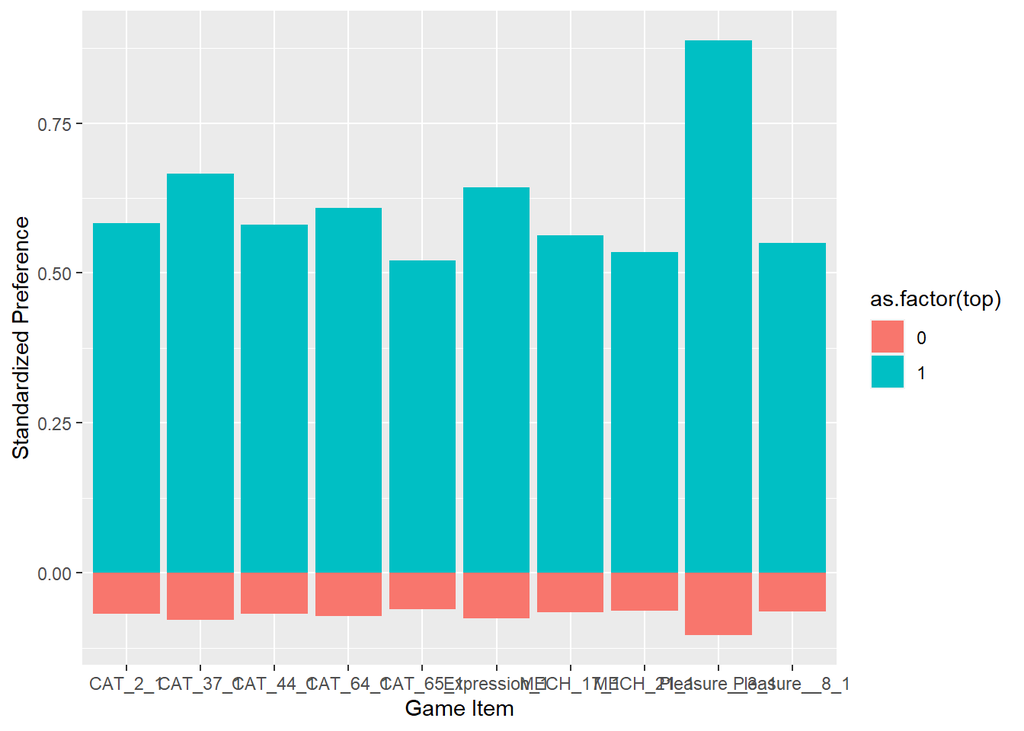

```r
GS_top5_pref_long <- pivot_longer(GS_top5_pref_long[1:2,], !top)


# Grouped
ggplot(GS_top5_pref_long, aes(x = name, y = value,  fill=as.factor(top))) +
    geom_bar(position="stack", stat="identity")+
  xlab("Game Item") +
  ylab("Standardized Preference")
```